# STAT_563_Project_2_Q1

Cecilia Albert-Black

2025-11-03

This project integrated large-sample theory, likelihood-based inference, and re-sampling techniques in modern computational statistics. In this Markdown file, I will:

- Examine the logistic distribution and its importance in statistical modeling and machine learning
- compute confidence intervals based on Fisher information
- Explore bootstrapping and the distribution of correlation matrices
- Implement slice sampling for correlation uncertainty

### Visualization and Interpretation of the Logistic Distribution

The logistic density is given by the function:

$$f(x| \mu, s) = \frac{e^{-\frac{x - \mu}{s}}}{s \left(1 + e^{-\frac{x -
\mu}{s}}\right)^2}$$

#### a. Plotting

Plot the density function for several parameter settings by overlaying the curves on the same axes:

- mu = 0 with s = 0.5, 1, 2 to study the effect of scale

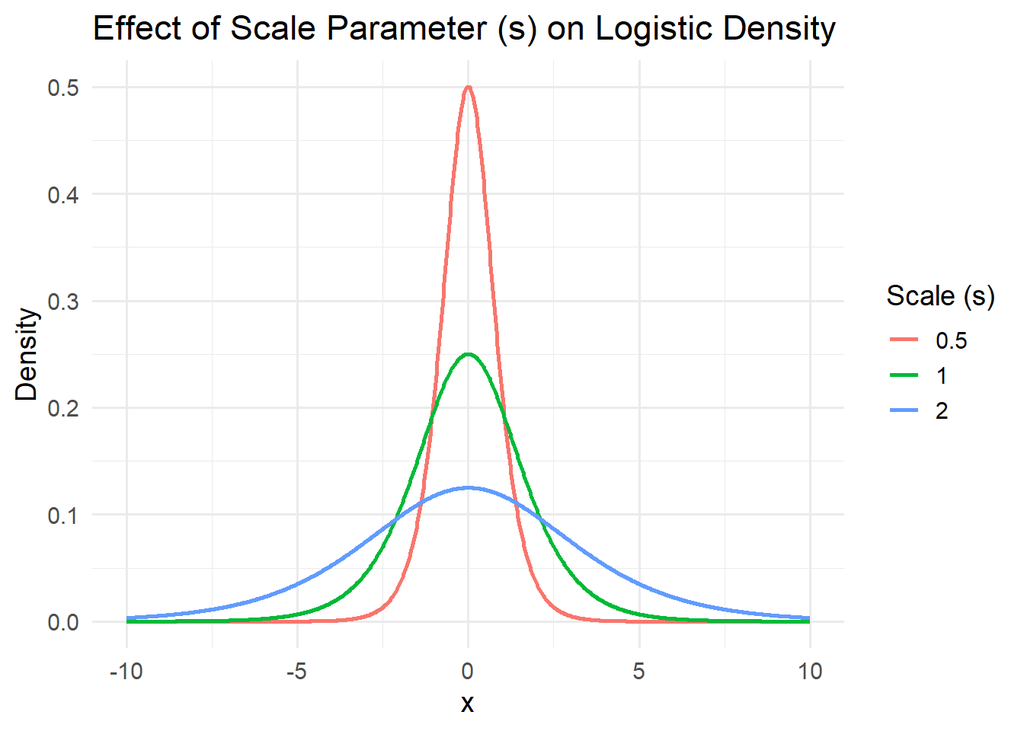

```r
# Load necessary library
library(ggplot2)

# Define the logistic density function
f_logistic <- function(x, mu, s) {
  exp(-(x - mu)/s) / (s * (1 + exp(-(x - mu)/s))^2)
}

# Create a sequence of x values for plotting
x <- seq(-10, 10, length.out = 1000)

# --- (a) Effect of scale parameter s ---
mu <- 0
s_values <- c(0.5, 1, 2)

# Compute densities for each s
dens_scale <- data.frame(
  x = rep(x, times = length(s_values)),
  f = unlist(lapply(s_values, function(s) f_logistic(x, mu, s))),
  s = factor(rep(s_values, each = length(x)))
)

# Plot: Effect of scale
ggplot(dens_scale, aes(x = x, y = f, color = s)) +
  geom_line(size = 1) +
  labs(
    title = "Effect of Scale Parameter (s) on Logistic Density",
    x = "x",
    y = "Density",
    color = "Scale (s)"
  ) +
  theme_minimal(base_size = 14)
```

- s = 1 with mu = -2, 0, 2 to study the effect of location

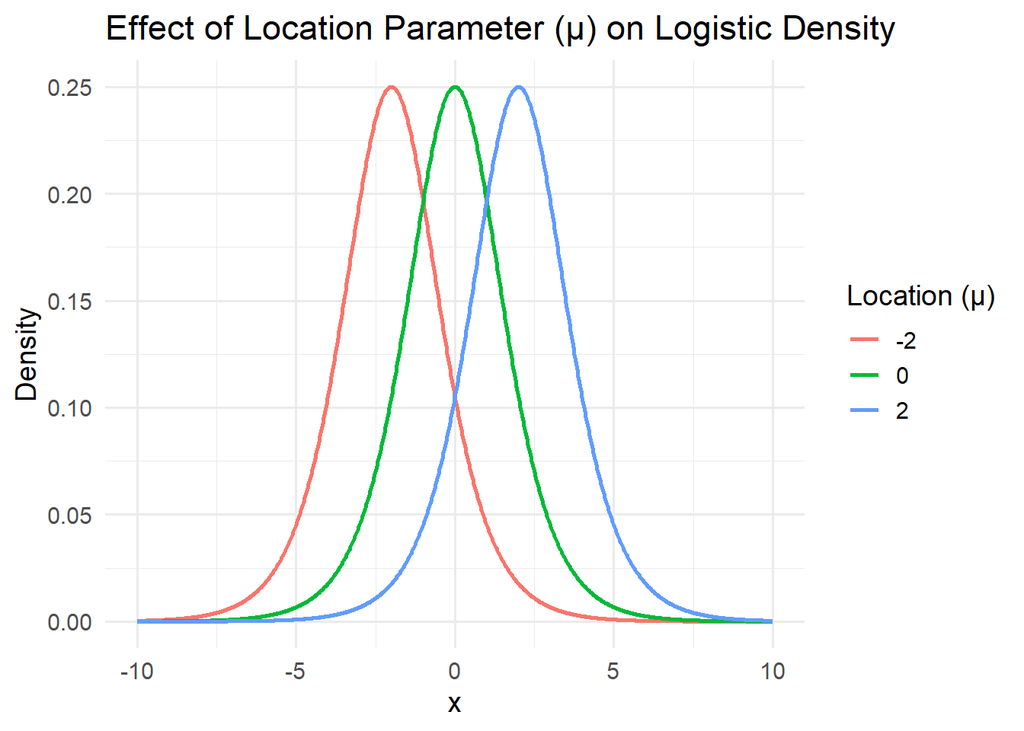

```r
s <- 1
mu_values <- c(-2, 0, 2)

# Compute densities for each mu
dens_location <- data.frame(
  x = rep(x, times = length(mu_values)),
  f = unlist(lapply(mu_values, function(mu) f_logistic(x, mu, s))),
  mu = factor(rep(mu_values, each = length(x)))
)

# Plot: Effect of location
ggplot(dens_location, aes(x = x, y = f, color = mu)) +
  geom_line(size = 1) +
  labs(
    title = "Effect of Location Parameter (μ) on Logistic Density",
    x = "x",
    y = "Density",
    color = "Location (μ)"
  ) +
  theme_minimal(base_size = 14)
```

#### b. Interpretation

- The location parameter μ shifts the curve horizontally, serving as both mean and median.
- The scale parameter s controls spread: larger s produces heavier tails and flatter curvature.
- The variance of logistic distribution is
  $$\mathrm{Var}(X) = \frac{\pi^2 s^2}{3}$$

#### c. Comparison with the Normal Distribution

Overlay f(x | 0, 1) with the standard normal N(0, 1). Discuss how the logistic distribution has heavier tails, offering more robustness to outliers.

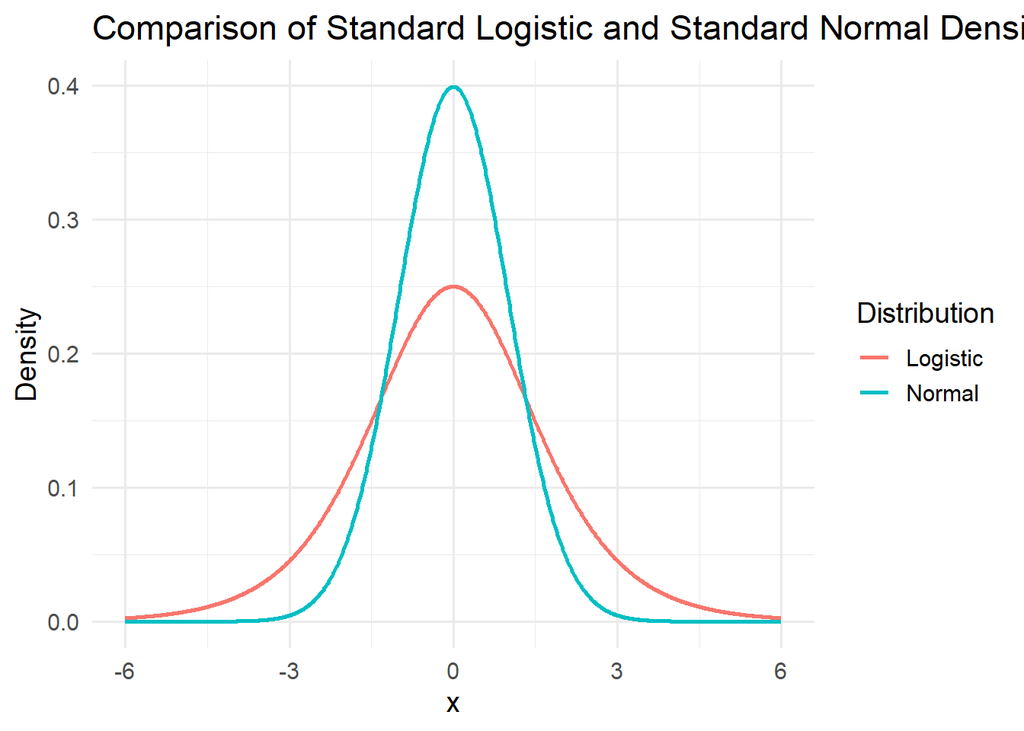

```r
# Load required library
library(ggplot2)

# Define the logistic PDF
f_logistic <- function(x, mu = 0, s = 1) {
  exp(-(x - mu)/s) / (s * (1 + exp(-(x - mu)/s))^2)
}

# Create a sequence of x values
x <- seq(-6, 6, length.out = 1000)

# Compute densities
densities <- data.frame(
  x = x,
  Logistic = f_logistic(x, mu = 0, s = 1),
  Normal = dnorm(x, mean = 0, sd = 1)
)

# Convert to long format for plotting
dens_long <- tidyr::pivot_longer(densities, cols = c("Logistic", "Normal"),
                                 names_to = "Distribution", values_to = "Density")

# Plot overlay
ggplot(dens_long, aes(x = x, y = Density, color = Distribution)) +
  geom_line(size = 1) +
  labs(
    title = "Comparison of Standard Logistic and Standard Normal Densities",
    x = "x",
    y = "Density",
    color = "Distribution"
  ) +
  theme_minimal(base_size = 14)
```

Both the standard logistic and standard normal distribution are symmetrical and bell-shaped centered around the mean (mu) at 0; however, the logistic curve has heavier tails than the normal. Heavier tails means that the density decreases more slowly as observations are farther from mu; in other words, it has a wider spread of values around the mean. This implies that the logistic distribution accounts for a higher probability of observing values farther from the mean compared to the normal distribution. As a result, models based on the logistic distribution are more robust to outliers, since they are less affected by large deviations from the mean.

#### d. Discuss the importance in Statistics and Machine Learning

- The logistic cumulative density function (CDF) is given by
  $$F(x \mid \mu, s) = \frac{1}{1 + e({-\frac{x - \mu}{s})}}$$

  which defines the canonical logit link in generalized linear models.
- In logistic regression, this CDF maps linear predictors to probabilities in (0,1).
- The heavier tails make logistic likelihoods more robust than Gaussian (Normal) ones.
- In machine learning (ML), logistic loss (cross-entropy) and softmax generalization underpin neural classification models.

**My interpretation of this is as follows:**

The logistic distribution is foundation at explaining probability-based outcomes in statistics, which is applicable to machine learning. In statistics, generalized linear models (GLMs) can use the logit link function to predict the outcome of a value based on a presence/absence or success/failure probability outcome.

While I have not learned much about machine learning yet, the logistic function appears to have a wide application in this field. It seems that the logistic distribution would be ideal when training a model to identify presence/absence of features within certain categories or criteria. I find it interesting that such a simple statistical distribution underlies much of the modern predictive modeling capabilities and I’m excited to learn more about it.